# Aula 9 - Econometria de Séries Temporais

João Ricardo F. de Lima

07 de maio de 2022.

# 1 Modelos ARCH-GARCH

Em geral, as análises feitas em econometria modelam a média condicional de uma variável aleatória $E(Y|X)$. Contudo, o modelo desta aula é diferente por modelar não a média mas sim a variância condicional (ou a volatidade) de uma variável.

Existem várias razões pelas quais se pode querer modelar e fazer previsão da volatilidade. Primeiro, você pode precisar analisar o risco de manter um ativo ou o valor de uma opção. Em segundo lugar, prever intervalos de confiança podem variar no tempo, de modo que intervalos mais precisos podem ser obtidos modelando a variância dos erros. Terceiro, estimadores mais eficientes podem ser obtidos se a heteroscedasticidade nos erros é tratada corretamente.

Os modelos de heterocedasticidade condicional autorregressiva (ARCH) são projetados especificamente para modelar e prever variâncias condicionais.

A variância da variável dependente é modelada em função dos valores passados da variável dependente e das independentes, ou variáveis exógenas

Os modelos ARCH foram introduzidos por Engle (1982) e generalizados como GARCH (Generalized ARCH) por Bollerslev (1986) e Taylor (1986). Estes modelos são amplamente utilizados em vários ramos da econometria, especialmente na análise de séries temporais financeiras.

Ao desenvolver um modelo ARCH, deve-se fornecer três especificações distintas - uma para a da equação média condicional, uma para a da variância condicional e outra para a da distribuição de erro condicional.

Especificamente em séries financeiras, a variância do resíduo varia ao longo do tempo de uma maneira que depende de quão elevados tenham sido os erros no passado. Muitas vezes há evidência de uma “aglomeração” de erros grandes e pequenos.

Assim, existe um tipo particular de heterocedasticidade presente, em que a variância do erro da regressão depende da volatilidade dos erros no passado recente.

Engle desenvolveu um modelo chamado de ARCH (Heterocedasticidade condicional autorregressiva) que considera este tipo de heterocedasticidade. Considere o modelo,

$$Y_t=\beta_1+\beta_2Y_{t-1}+\epsilon_t$$

E uma equação que relaciona a variância do erro ao tamanho da volatilidade observada em períodos recentes, cuja forma mais simples seria

$$\sigma_t^2=\alpha_0+\alpha_1\epsilon_{t-1}^2$$

A equação acima diz que a variância de $\epsilon_t$, $\sigma_{t}^2$ tem dois componentes: uma constante e as novidades do último período sobre volatilidade, que se modela com o resíduo quadrado do último período, chamado de termo ARCH.

O resíduo $\epsilon_t$ é heterocedástico, condicional a $\epsilon_{t-1}$. Ao levar em consideração essa informação sobre a heterocedasticidade condicional de $\epsilon_t$, se obtêm estimativas mais eficientes dos parâmetros $\beta_1,\beta_2,\beta_3$.

Como a variância de $\epsilon_t$ na equação acima depende apenas da volatilidade do último período, este modelo é denominado de ARCH(1).

Generalizando, a variância poderia depender de qualquer número de volatilidades defasadas. Assim, o ARCH(p) é definido como

$$\sigma_t^2=\alpha_0+\alpha_1\epsilon_{t-1}^2+\alpha_2\epsilon_{t-2}^2+
\dots + \alpha_p\epsilon_{t-p}^2$$

todos os p+1 parâmetros e os $\beta's$ são estimados conjuntamente por máxima verossimilhança.

A série em nível tem aparência de maior variabilidade para valores mais altos da série; Testes de raiz unitária indicam que não são estacionárias em nível.

A série de retornos, definida por $r_t=ln(y_t)-ln(y_{t-1})$ parece estacionária mas com períodos alternados de alta e baixa variabilidade (aglomerados de volatilidade).

Em geral, os retornos não são autocorrelacionados mas também não são IID (independente e igualmente distribuídos).

A distribuição dos retornos apresenta-se não normal, pelo teste de Jarque-Bera.

## 1.1 Restrições no Modelos ARCH

As séries com efeito ARCH possuem algumas características:

1. Para garantir variância positiva e estacionariedade do modelo é necessário impor restrições nos parâmetros do modelo. Para um ARCH(p)

$$\sigma_t^2=\alpha_0+\alpha_1\epsilon_{t-1}^2+\alpha_2\epsilon_{t-2}^2+
\dots + \alpha_p\epsilon_{t-p}^2$$

a condição suficiente para variância condicional positiva é que

$\alpha_0>0$ e $\alpha_p \ge 0$ para todo i, com i=1,2,3,…,p. a condição necessária para que a série seja estacionária é que o $\sum_{i=1}^{p}\alpha_i < 1$;

## 1.2 Deficiências no Modelos ARCH

Dentre as deficiências do modelo, as mais relevantes são a superestimação da volatilidade e tratar erros positivos e negativos da mesma forma.

O modelo não capta assimetria do impacto do retorno do erro sobre a volatilidade. Na prática, a volatilidade dos retornos de uma ativo financeiro reage de forma diferente a retornos positivos (subida de preços) e negativos (queda de preços).

Uma das dificuldades do Modelo ARCH é a necessidade de ajustar modelos de ordem muito grande. Bollerslev (1986) propôs um modelo ARCH Generalizado, chamado de GARCH que é normalmente mais parcimonioso. A literatura sugere que se estime um GARCH quando o ARCH a ser estimado for de ordem superior a 3.

O GARCH considera a variância condicional como função dos erros passados ao quadrado e de valores defasados da variância condicional.

Um modelo GARCH (p,q) é definido por

$$\sigma_t^2=\omega+\sum_{j=1}^{p}\beta_j\sigma_{t-j}^2+\sum_{i=1}^{q}\alpha_j\epsilon_{t-i}^2$$

A equação modela a variância condicional, sendo função de três termos: a) constante; b) volatilidade fo período anterior (termo ARCH)e a variância prevista do último período (termo GARCH).

O (1, 1) em GARCH (1, 1) refere-se à presença de um termo GARCH autorregressivo de primeira ordem (o primeiro termo entre parênteses) e um termo ARCH de média móvel de primeira ordem (o segundo em parênteses). Um modelo ARCH comum é um caso especial de uma especificação GARCH em que não há variações de previsão defasadas na equação de variância condicional - isto é, um GARCH (0, 1).

Esta especificação é freqüentemente interpretada em um contexto financeiro, onde um agente prediz a variação deste período formando uma média ponderada de uma média de longo prazo (a constante), a variância prevista do último período (o termo GARCH) e informações sobre volatilidade observada no período anterior (o termo ARCH).

Se o retorno do ativo foi inesperadamente grande no sentido ascendente ou descendente, o agente aumentará a estimativa da variância para o próximo período. Este modelo também é consistente com o cluster (aglomeração) de volatilidade, muitas vezes visto em dados de retornos financeiros, onde grandes mudanças nos retornos são seguido por outras grandes mudanças.

Modelos GARCH de ordem mais alta, denotados GARCH (p,q), podem ser estimados escolhendo tanto q ou p maior que 1, onde p está a ordem dos termos GARCH auto-regressivos e q é a ordem dos termos de média móvel do ARCH.

## 1.3 Entrada de dados no R

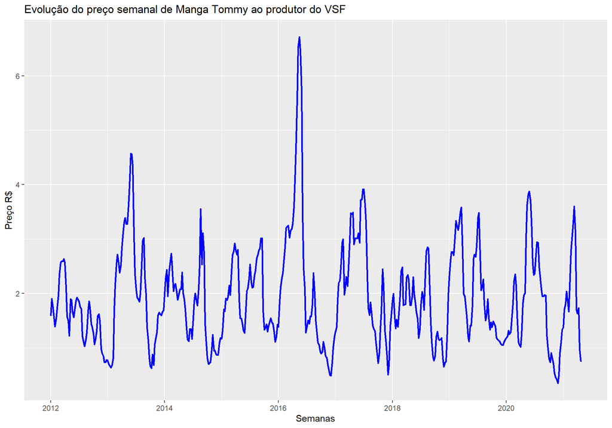

```r
#Direcionado o R para o Diretorio a ser trabalhado
setwd('C:/Users/Joao Ricardo Lima/Dropbox/tempecon/facape/econometria2')

#Inicio do Script

#Pacotes a serem usados
library(forecast)
library(ggplot2)
#library(easyGgplot2)
library(urca)
library(stargazer)
library(tseries)
library(lmtest)
library(ggthemes)
library(zoo)
library(xts)
library(FinTS)
library(scales)
library(uroot)
library(fGarch)

options(digits=4)
#options(scipen = 999)
#options(scipen = 0)

#Extracao dos dados
dados <- read.csv2('dados_manga_tommy_semana.csv', header=T, sep=";", dec=".")
#dados <- dados[,-c(9:10)] #retirar as ultimas colunas
colnames(dados)[1]<-'produto'

#Entrando dados no R - Deflator
igpdi <- read.csv2('igpdi.csv',
                   header=T, sep=";",
                   dec=".")

#Juntando as duas bases de dados
dados_comb<-cbind(dados, igpdi)

#Retira variaveis desnecessarias
dadost<-dados_comb[,-c(1,2,6,7)]

#Deflacionar a serie de manga
dadost$preco_def <- dadost[,3]*(tail(dadost[,4],1)/dadost[,4])


#Analise de Serie Temporal
preco_tommy <- dadost[,5]

#Setando como serie temporal
preco_tommy <- ts(preco_tommy, start=c(2012,1), freq=52)

#Grafico da Série
autoplot(preco_tommy, main='Evolução do preço semanal de Manga Tommy ao produtor do VSF') +
  geom_line(colour="blue", size=1.0) + xlab('Semanas')+ ylab('Preço R$')
```

## 1.4 Análise da Raiz Unitária

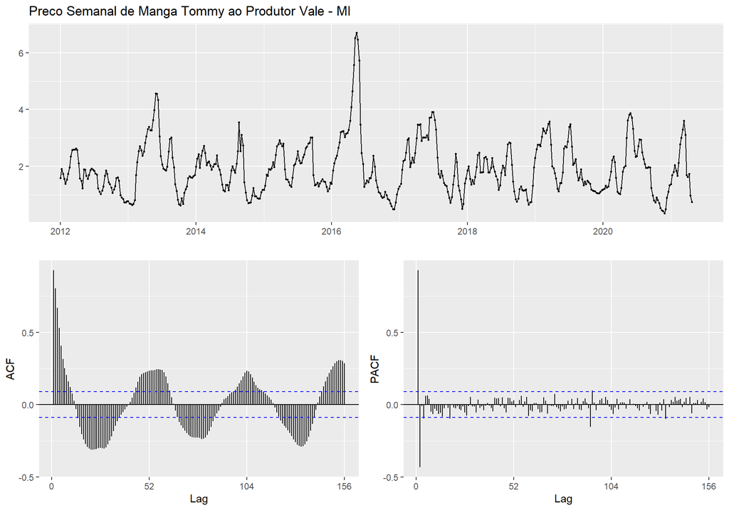

```r
#Visualizando as correlações das series
#INICIO DAS ANALISES PARA PREVISÃO
ggtsdisplay(preco_tommy, main='Preco Semanal de Manga Tommy ao Produtor Vale - MI')
```

```r
#Teste de Raiz Unitaria na Serie
#Verificacao da Estacionariedade das s?ries
#Teste de raiz unitaria DF-GLS
#Defini??o do numero m?ximo de lags
print(12*(length(preco_tommy)/100)^(1/4))
```

```
# [1] 17.81
```

```r
#Estatistica de Teste DFGLS para preco_tommy
preco_tommyT.dfgls <- ur.ers(preco_tommy, type = c("DF-GLS"),
                      model = c("trend"),
                      lag.max = 17)
summary(preco_tommyT.dfgls)
```

```
#
# ###############################################
# # Elliot, Rothenberg and Stock Unit Root Test #
# ###############################################
#
# Test of type DF-GLS
# detrending of series with intercept and trend
#
#
# Call:
# lm(formula = dfgls.form, data = data.dfgls)
#
# Residuals:
#     Min      1Q  Median      3Q     Max
# -1.4587 -0.1110  0.0347  0.1893  1.0462
#
# Coefficients:
#               Estimate Std. Error t value Pr(>|t|)
# yd.lag        -0.13265    0.02442   -5.43  9.1e-08 ***
# yd.diff.lag1   0.46751    0.04761    9.82  < 2e-16 ***
# yd.diff.lag2   0.00981    0.05211    0.19   0.8508
# yd.diff.lag3   0.13891    0.05174    2.68   0.0075 **
# yd.diff.lag4  -0.02556    0.05196   -0.49   0.6230
# yd.diff.lag5   0.02011    0.05259    0.38   0.7023
# yd.diff.lag6  -0.03241    0.05245   -0.62   0.5369
# yd.diff.lag7   0.06212    0.05246    1.18   0.2370
# yd.diff.lag8   0.08146    0.05224    1.56   0.1196
# yd.diff.lag9   0.03667    0.05223    0.70   0.4830
# yd.diff.lag10  0.02034    0.05234    0.39   0.6977
# yd.diff.lag11  0.06852    0.05221    1.31   0.1901
# yd.diff.lag12  0.04654    0.05174    0.90   0.3688
# yd.diff.lag13  0.08824    0.05159    1.71   0.0879 .
# yd.diff.lag14  0.01277    0.05125    0.25   0.8034
# yd.diff.lag15 -0.00910    0.05125   -0.18   0.8592
# yd.diff.lag16 -0.02343    0.05109   -0.46   0.6467
# yd.diff.lag17  0.09837    0.04834    2.03   0.0425 *
# ---
# Signif. codes:  0 '***' 0.001 '**' 0.01 '*' 0.05 '.' 0.1 ' ' 1
#
# Residual standard error: 0.31 on 449 degrees of freedom
# Multiple R-squared:  0.256,   Adjusted R-squared:  0.226
# F-statistic:  8.6 on 18 and 449 DF,  p-value: <2e-16
#
#
# Value of test-statistic is: -5.432
#
# Critical values of DF-GLS are:
#                  1pct  5pct 10pct
# critical values -3.48 -2.89 -2.57
```

```r
#Teste de Raiz Unitaria Sazonal HEGY
hegy.test(preco_tommy, deterministic = c(1,1,0), lag.method = "AIC")
```

```
#
#   HEGY test for unit roots
#
# data:  preco_tommy
#
#         statistic p-value
# t_1         -2.93    0.08 .
# t_2          -2.9       0 **
# F_3:4        2.56    0.07 .
# F_5:6        5.92       0 **
# F_7:8        6.48       0 **
# F_9:10        6.8       0 ***
# F_11:12      9.53       0 ***
# F_13:14     10.06       0 ***
# F_15:16     11.74       0 ***
# F_17:18      4.87    0.01 **
# F_19:20      6.39       0 **
# F_21:22      6.59       0 ***
# F_23:24      9.23       0 ***
# F_25:26      3.73    0.02 *
# F_27:28      6.41       0 **
# F_29:30      6.83       0 ***
# F_31:32      8.94       0 ***
# F_33:34      9.88       0 ***
# F_35:36      9.43       0 ***
# F_37:38      6.61       0 ***
# F_39:40      7.35       0 ***
# F_41:42      6.14       0 **
# F_43:44      5.99       0 **
# F_45:46      6.13       0 **
# F_47:48      8.46       0 ***
# F_49:50      8.86       0 ***
# F_51:52      7.31       0 ***
# F_2:52     104.06       0 ***
# F_1:52     102.63       0 ***
# ---
# Signif. codes: 0 '***' 0.001 '**' 0.01 '*' 0.05 '.' 0.1 ' ' 1
#
# Deterministic terms: constant + trend
# Lag selection criterion and order: AIC, 0
# P-values: based on response surface regressions
```

## 1.5 Estimação do Modelo ARIMA e verificação de ARCH

```r
#Estimacao do Modelo Auto-ARIMA
auto.arima <- auto.arima(preco_tommy, max.p=10, max.d=1, max.D=1, max.q=10, max.P=10, max.Q=10,
                         seasonal = T, trace = TRUE)
```

```
#
#  Fitting models using approximations to speed things up...
#
#  ARIMA(2,0,2)(1,0,1)[52] with non-zero mean : 290.2
#  ARIMA(0,0,0)            with non-zero mean : 1322
#  ARIMA(1,0,0)(1,0,0)[52] with non-zero mean : 379.6
#  ARIMA(0,0,1)(0,0,1)[52] with non-zero mean : 784.7
#  ARIMA(0,0,0)            with zero mean     : 2122
#  ARIMA(2,0,2)(0,0,1)[52] with non-zero mean : 242.8
#  ARIMA(2,0,2)            with non-zero mean : 241.8
#  ARIMA(2,0,2)(1,0,0)[52] with non-zero mean : 271
#  ARIMA(1,0,2)            with non-zero mean : 249.1
#  ARIMA(2,0,1)            with non-zero mean : 241.2
#  ARIMA(2,0,1)(1,0,0)[52] with non-zero mean : 271.7
#  ARIMA(2,0,1)(0,0,1)[52] with non-zero mean : 242.2
#  ARIMA(2,0,1)(1,0,1)[52] with non-zero mean : 273.7
#  ARIMA(1,0,1)            with non-zero mean : 253.7
#  ARIMA(2,0,0)            with non-zero mean : 239.2
#  ARIMA(2,0,0)(1,0,0)[52] with non-zero mean : 269.9
#  ARIMA(2,0,0)(0,0,1)[52] with non-zero mean : 240.2
#  ARIMA(2,0,0)(1,0,1)[52] with non-zero mean : 271.9
#  ARIMA(1,0,0)            with non-zero mean : 346.2
#  ARIMA(3,0,0)            with non-zero mean : 241.1
#  ARIMA(3,0,1)            with non-zero mean : 242.3
#  ARIMA(2,0,0)            with zero mean     : 270.1
#
#  Now re-fitting the best model(s) without approximations...
#
#  ARIMA(2,0,0)            with non-zero mean : 240.5
#
#  Best model: ARIMA(2,0,0)            with non-zero mean
```

```r
summary(auto.arima)
```

```
# Series: preco_tommy
# ARIMA(2,0,0) with non-zero mean
#
# Coefficients:
#         ar1     ar2   mean
#       1.349  -0.448  1.918
# s.e.  0.041   0.041  0.139
#
# sigma^2 = 0.0947:  log likelihood = -116.2
# AIC=240.4   AICc=240.5   BIC=257.2
#
# Training set error measures:
#                     ME   RMSE    MAE    MPE  MAPE   MASE      ACF1
# Training set 0.0006023 0.3067 0.2148 -2.815 12.62 0.2539 -0.003698
```

```r
coeftest(auto.arima)
```

```
#
# z test of coefficients:
#
#           Estimate Std. Error z value Pr(>|z|)
# ar1         1.3490     0.0405    33.3   <2e-16 ***
# ar2        -0.4485     0.0406   -11.1   <2e-16 ***
# intercept   1.9181     0.1387    13.8   <2e-16 ***
# ---
# Signif. codes:  0 '***' 0.001 '**' 0.01 '*' 0.05 '.' 0.1 ' ' 1
```

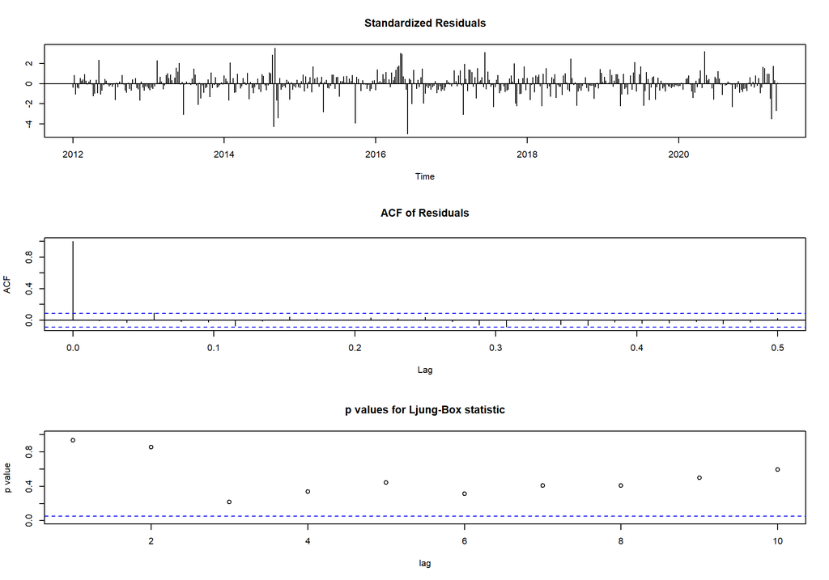

```r
tsdiag(auto.arima)
```

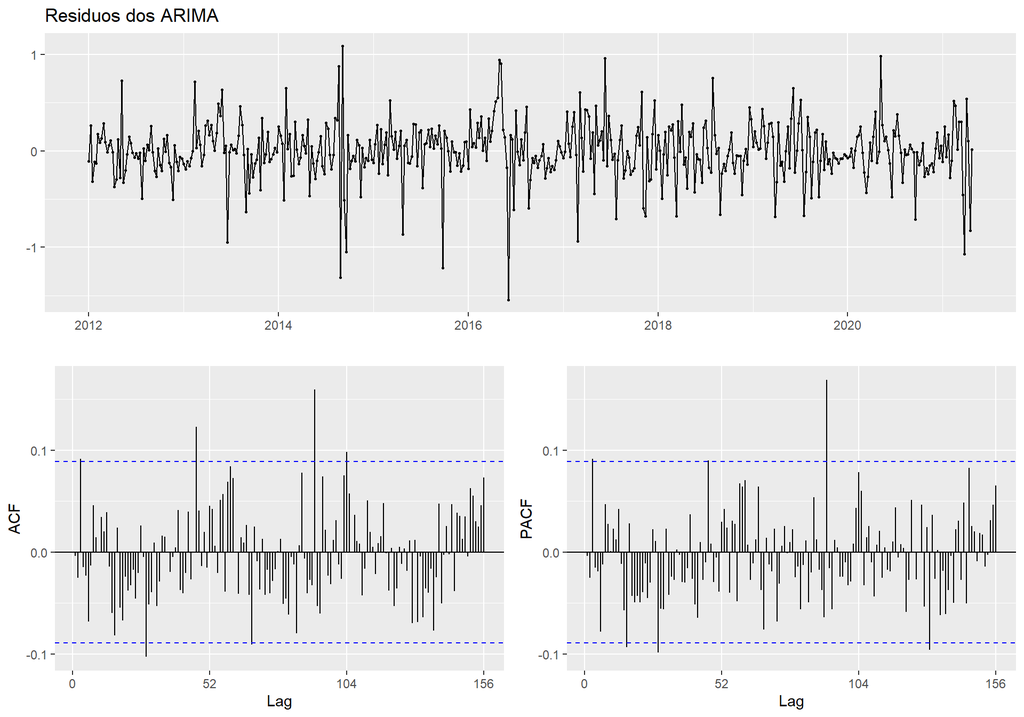

```r
#Visualizando a correlação dos resíduos
ggtsdisplay(auto.arima$residuals, main='Residuos dos ARIMA')
```

```r
#Teste de Ljung Box para autocorrelação nos resíduos
#Hipotese nula do teste é que os residuos nao sao autocorrelacionados
Box.test(auto.arima$residuals, lag=40,
         type="Ljung-Box", fitdf=length(coef(auto.arima)))
```

```
#
#   Box-Ljung test
#
# data:  auto.arima$residuals
# X-squared = 34, df = 37, p-value = 0.6
```

```r
#Teste para verificar se os residuos seguem ARCH
#H0: Não existe efeito ARCH
ArchTest(auto.arima$residuals, lags = 1, demean = TRUE)
```

```
#
#   ARCH LM-test; Null hypothesis: no ARCH effects
#
# data:  auto.arima$residuals
# Chi-squared = 14, df = 1, p-value = 1e-04
```

# 2 Estimação do modelo ARCH

```r
arch01 <- garch(auto.arima$residuals, order = c(0,1), trace=FALSE)
arch02 <- garch(auto.arima$residuals, order = c(0,2), trace=FALSE)
arch03 <- garch(auto.arima$residuals, order = c(0,3), trace=FALSE)
garch11 <- garch(auto.arima$residuals, order = c(1,1), trace=FALSE)
garch22 <- garch(auto.arima$residuals, order = c(2,2), trace=FALSE)

#Escolha do modelo ARCH com AICc -
N <- length(preco_tommy)
loglik0 <- -0.5 * N * (1 + log(2 * pi * mean(auto.arima$residuals^2)))
loglik1 <- logLik(arch01)
loglik2 <- logLik(arch02)
loglik3 <- logLik(arch03)
loglik4 <- logLik(garch11)
loglik5 <- logLik(garch22)

loglik <- c(loglik0, loglik1, loglik2, loglik3, loglik4, loglik5)
q <- c(0, 1, 2, 3, 4, 5)
k <- q + 1
aicc <- -2 * loglik  + 2 * k * N / (N - k - 1)
aicc
```

```
# [1] 232.0 212.6 214.5 210.9 210.4 211.3
```

```r
#stargazer(print(data.frame(q, loglik, aicc)))

#Modelo Escolhido
fit.arch <- garch(auto.arima$residuals, c(1, 1), trace=FALSE)
summary(fit.arch)
```

```
#
# Call:
# garch(x = auto.arima$residuals, order = c(1, 1), trace = FALSE)
#
# Model:
# GARCH(1,1)
#
# Residuals:
#     Min      1Q  Median      3Q     Max
# -4.5913 -0.4578 -0.0218  0.5718  3.6123
#
# Coefficient(s):
#     Estimate  Std. Error  t value Pr(>|t|)
# a0   0.02207     0.00473     4.67  3.1e-06 ***
# a1   0.12640     0.03262     3.87  0.00011 ***
# b1   0.64055     0.06534     9.80  < 2e-16 ***
# ---
# Signif. codes:  0 '***' 0.001 '**' 0.01 '*' 0.05 '.' 0.1 ' ' 1
#
# Diagnostic Tests:
#   Jarque Bera Test
#
# data:  Residuals
# X-squared = 164, df = 2, p-value <2e-16
#
#
#   Box-Ljung test
#
# data:  Squared.Residuals
# X-squared = 0.013, df = 1, p-value = 0.9
```

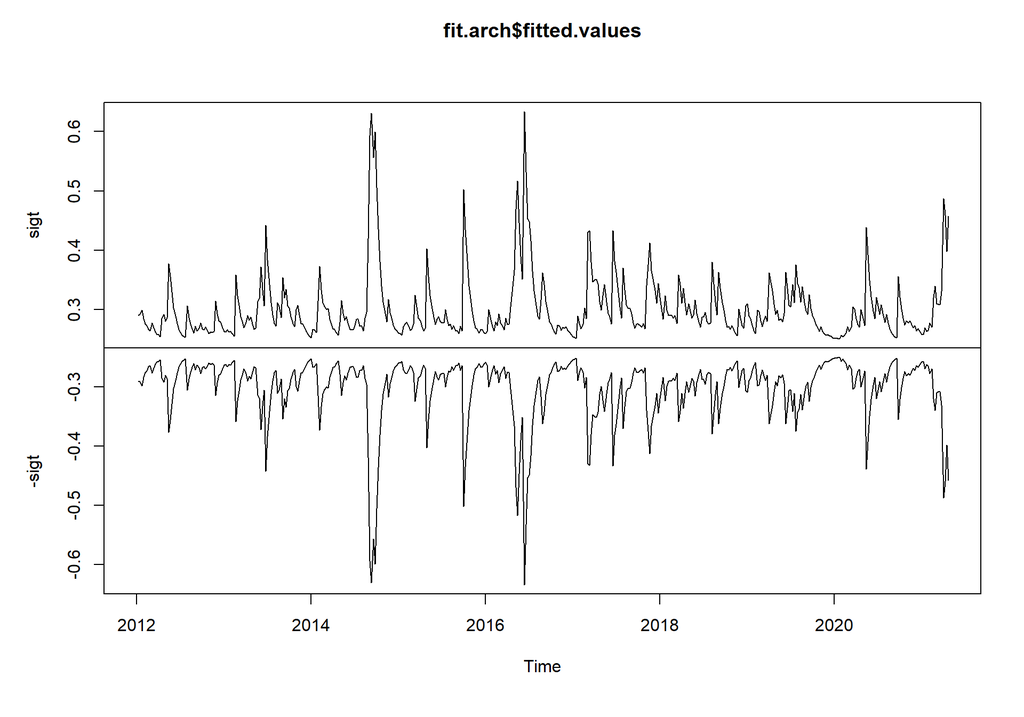

```r
plot.ts(fit.arch$fitted.values)
```

```r
fit.garch <- garchFit(~garch(1,1), data = auto.arima$residuals, trace = F)
summary(fit.garch)
```

```
#
# Title:
#  GARCH Modelling
#
# Call:
#  garchFit(formula = ~garch(1, 1), data = auto.arima$residuals,
#     trace = F)
#
# Mean and Variance Equation:
#  data ~ garch(1, 1)
# <environment: 0x00000225319762f8>
#  [data = auto.arima$residuals]
#
# Conditional Distribution:
#  norm
#
# Coefficient(s):
#         mu       omega      alpha1       beta1
# -0.0060226   0.0216661   0.1298703   0.6413824
#
# Std. Errors:
#  based on Hessian
#
# Error Analysis:
#         Estimate  Std. Error  t value Pr(>|t|)
# mu     -0.006023    0.013659   -0.441  0.65927
# omega   0.021666    0.006907    3.137  0.00171 **
# alpha1  0.129870    0.041154    3.156  0.00160 **
# beta1   0.641382    0.087651    7.317 2.53e-13 ***
# ---
# Signif. codes:  0 '***' 0.001 '**' 0.01 '*' 0.05 '.' 0.1 ' ' 1
#
# Log Likelihood:
#  -99.41    normalized:  -0.205
#
# Description:
#  Sat May  7 14:03:21 2022 by user: Joao Ricardo Lima
#
#
# Standardised Residuals Tests:
#                                 Statistic p-Value
#  Jarque-Bera Test   R    Chi^2  162.2     0
#  Shapiro-Wilk Test  R    W      0.9584    1.851e-10
#  Ljung-Box Test     R    Q(10)  6.501     0.7716
#  Ljung-Box Test     R    Q(15)  10.54     0.7845
#  Ljung-Box Test     R    Q(20)  20.41     0.4327
#  Ljung-Box Test     R^2  Q(10)  3.472     0.9681
#  Ljung-Box Test     R^2  Q(15)  7.606     0.9386
#  Ljung-Box Test     R^2  Q(20)  9.778     0.972
#  LM Arch Test       R    TR^2   4.064     0.9823
#
# Information Criterion Statistics:
#    AIC    BIC    SIC   HQIC
# 0.4264 0.4609 0.4263 0.4400
```

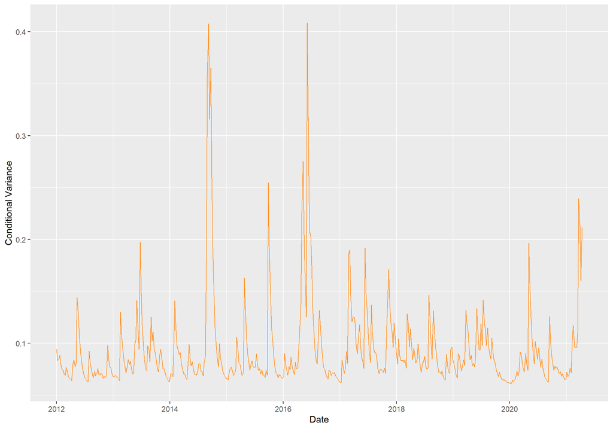

```r
dados$resid<-auto.arima$residuals
dados$ht <- fit.garch@h.t
dados$date <- seq.Date(as.Date('2012-01-01'), by = 'week', length.out = length(preco_tommy))
ggplot(dados, aes(y = ht, x = date)) + geom_line(col = '#ff9933') + ylab('Conditional Variance') + xlab('Date')
```

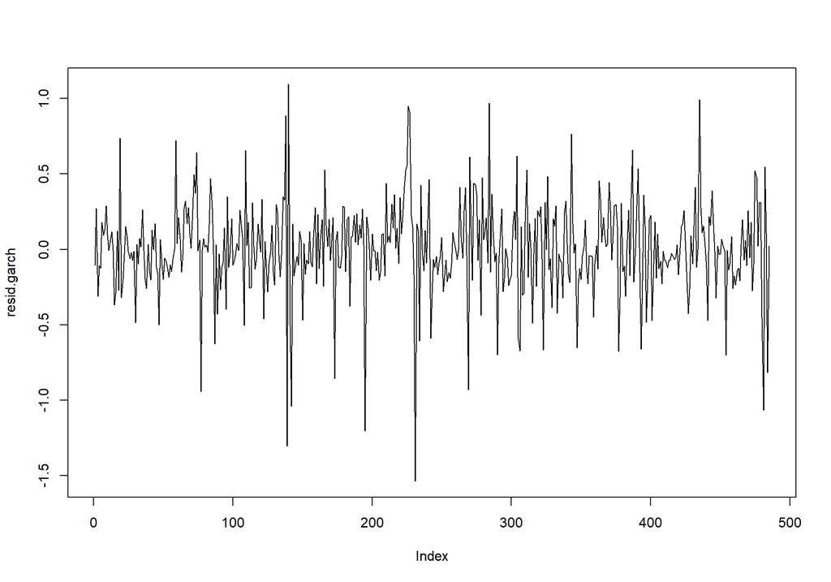

```r
#Diagnostico com os residuos do GARCH
resid.garch <- residuals(fit.garch)
plot(resid.garch, type="l", col=1)
```

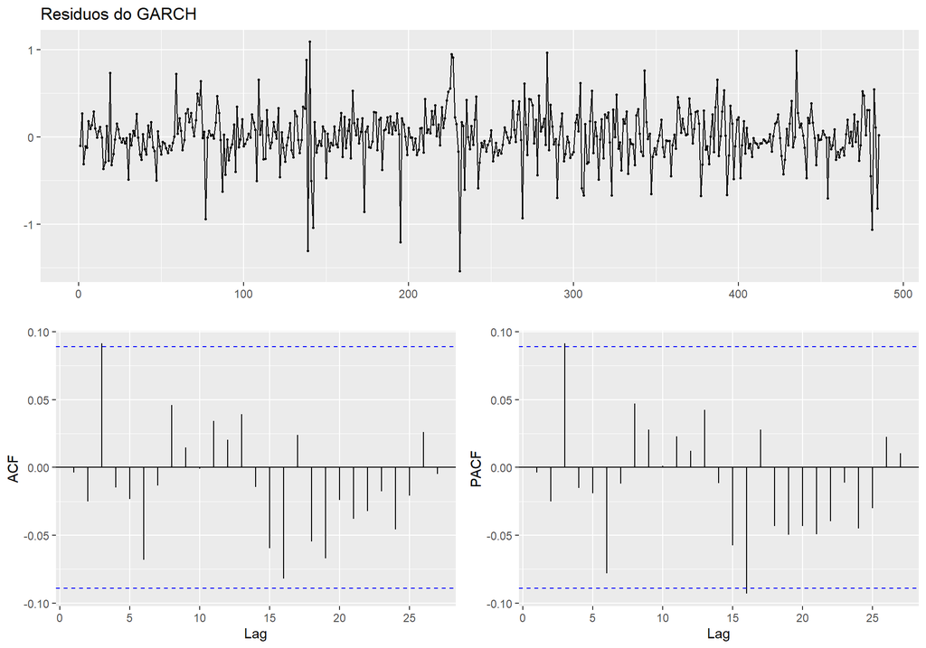

```r
#Ver se os res?duos sao ruido branco
ggtsdisplay(resid.garch, main='Residuos do GARCH')
```